# Computional Intelligence CSE3CI Assignment

1. Remove outliers of the output variable from the datasets (both training and test), and give a list of the outliers; and then rebuild the training and the test datasets; insert required libraries,loading data and detecting outliners

### insert required libraries,loading data and detecting outliners

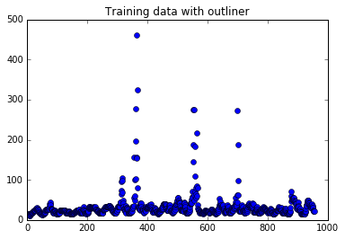

```python
import csv
import sys
import numpy as np
import matplotlib.pyplot as plt
import skfuzzy as fuzz
from skfuzzy import control as ctrl
%matplotlib inline

with open('2018_CI_Assignment_Training_Data.csv') as csvfile:
    readCSV = csv.reader(csvfile, delimiter=',')
    data = [r for r in readCSV]
    data.pop(0) #remove header row

dataArray=np.asanyarray(data,dtype='f') #save data from training file to array
plt.plot(dataArray[:,6],'o')
plt.title('Training data with outliner')
plt.show()
```

### Remove outliers and create a list of outliners

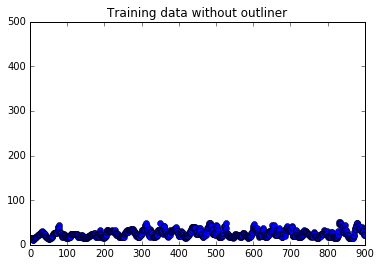

[output not shown]

```python
Q1=np.percentile(dataArray[:,6], 25);  # the value 25 is fixed for every problem;
Q3=np.percentile(dataArray[:,6], 75); # the value 75 is fixed for every problem;
range=[Q1-1.5*(Q3-Q1),Q3+1.5*(Q3-Q1)];
position=np.concatenate((np.where(dataArray[:,6]>range[1]),np.where(dataArray[:,6]<range[0])),axis=1) # np.concatenate is used for combining arrays
p_new= np.delete(dataArray, position,axis=0)   # np.delete is used for removing some elements in certain positions/places in a list

len(p_new)
plt.plot(p_new[:,6],'o')
plt.title('Training data without outliner')
plt.ylim(0, 500)
plt.show()
outliners=[]
p_new_max=np.max(p_new[:,6]) #get max value of new data set
count=0
rows=p_new.shape[0] # get number of rows in data

while count<rows:
    if(dataArray[count,6]>p_new_max): #create list of ouliners
        outliners.append(dataArray[count,6])
    count+=1
print("list of outliers:")
print(outliners)
```

### apply for testing dataset to remove outliners.

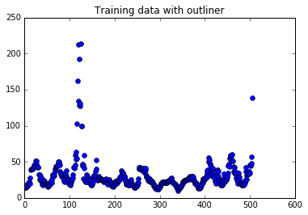

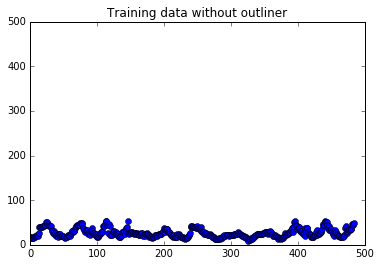

```
[59.53, 63.49, 102.73, 162.74, 213.1, 134.67, 192.36, 128.53, 127.75, 131.21, 213.88, 99.3, 99.3, 59.32, 56.08, 59.05, 58.03, 58.13, 60.12]
```

```python
with open('2018_CI_Assignment_Testing_Data.csv') as csvfile:
    readCSV = csv.reader(csvfile, delimiter=',')
    dataTesting = [r for r in readCSV]
    dataTesting.pop(0)

arrayTesting=np.asanyarray(dataTesting,dtype='f')
#p=array[:,6]

plt.plot(arrayTesting[:,6],'o')
plt.title('Training data with outliner')
plt.show()

Q1=np.percentile(arrayTesting[:,6], 25);  # the value 25 is fixed for every problem;
Q3=np.percentile(arrayTesting[:,6], 75); # the value 75 is fixed for every problem;
range=[Q1-1.5*(Q3-Q1),Q3+1.5*(Q3-Q1)];
position=np.concatenate((np.where(arrayTesting[:,6]>range[1]),np.where(arrayTesting[:,6]<range[0])),axis=1) # np.concatenate is used for combining arrays
p_new_testing= np.delete(arrayTesting, position,axis=0)   # np.delete is used for removing some elements in certain positions/places in a list
oo=(p_new_testing.shape)
len(p_new_testing)
plt.plot(p_new_testing[:,6],'o')
plt.title('Training data without outliner')
plt.ylim(0, 500)
plt.show()
outlinersTesting=[]
p_new_max=np.max(p_new_testing[:,6]) #get max value of new data set

count=0

while count<p_new_testing.shape[0]:

    if(arrayTesting[count,6]>p_new_max): #create list of ouliners
        outlinersTesting.append(arrayTesting[count,6])

    count+=1
print(outlinersTesting)
```

## correlation analysis

```python
#create a input maxtrix for correlation analysis
inputMatrix=np.column_stack(p_new)
#x1=np.linspace(1, 10, 100)

#calculate the Correlation Coefficient Matrix
CCM=np.corrcoef(inputMatrix)
print('Correlation analysis:')
print(CCM)
print()
print(CCM.shape)
```

```
Correlation analysis:
[[1.         0.97711422 0.94083427 0.43523076 0.49341031 0.54010843
  0.49325378]
 [0.97711422 1.         0.97678556 0.37103656 0.43915887 0.49715252
  0.46219849]
 [0.94083427 0.97678556 1.         0.29729517 0.37354106 0.44142235
  0.41799109]
 [0.43523076 0.37103656 0.29729517 1.         0.98603698 0.9497314
  0.52955784]
 [0.49341031 0.43915887 0.37354106 0.98603698 1.         0.98603361
  0.56492116]
 [0.54010843 0.49715252 0.44142235 0.9497314  0.98603361 1.
  0.58770781]
 [0.49325378 0.46219849 0.41799109 0.52955784 0.56492116 0.58770781
  1.        ]]

(7, 7)
```

The original data has M={T(t-2), T(t-1), T(t), D(t-2), D(t-1), D(t)}. But base on the Correlation analysis we just get M1={(t-2),D(t),P(t+1)} as our inputs and output.

```python
#based on coef analysis the new data set will be (T(t-2),D(t),P(t+1))
new_data_set=p_new[:, [0,5, 6]] #extract data from the original colunms
```

Display histogram of inputs and output

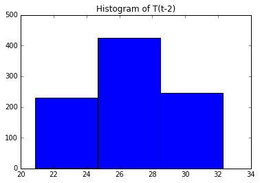

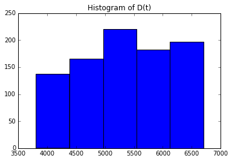

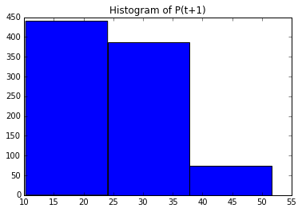

```python
plt.hist(new_data_set[:,0], 3) # histogram for input1
plt.title('Histogram of T(t-2)')
plt.ylim(0, 500)
plt.show()
plt.hist(new_data_set[:,1], 5) # histogram for input2
plt.title('Histogram of D(t)')
plt.show()
plt.hist(new_data_set[:,2], 3) # histogram for output
plt.title('Histogram of P(t+1)')
plt.show()
```

From the histograms create linguistic variables and their terms: Temperature T(t-2):low , warm hot Demand D(t): very little, little, average, high, very high PRR P(t+1): low, medium, high

### Create Antecedent/Consequent objects hold universe variables

in this step we also pass the data to each object. The main purpose of this is prepare for the next step,because we want to get the fuzzy values record from the original data .

```python
temperature= ctrl.Antecedent(new_data_set[:,0],'temperature')
demand=ctrl.Antecedent(new_data_set[:,1],'demand')
price=ctrl.Consequent(new_data_set[:,2],'price')
```

### Fuzzy membership functions

In this we pass data from traning dataset to membership function. The result will be fuzzy values for each record in traning data

```
shape of fuzzyValuesForInput1  (901, 3)
```

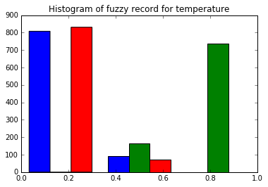

```
shape of fuzzyValuesForInput2  (901, 5)
```

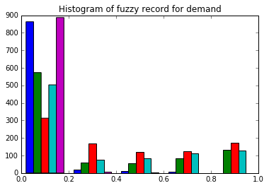

```
shape of fuzzyValuesForOutput  (901, 3)
```

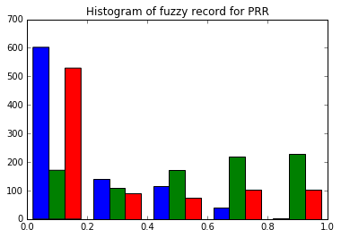

```python
#passing 1st colunm into three function and get the fuzzy values coresponding to each function
A1=temperature['low']=fuzz.trimf(temperature.universe,[16,16,27])
A2=temperature['warm']=fuzz.trimf(temperature.universe,[16,27,37])
A3=temperature['hot']=fuzz.trimf(temperature.universe,[27,37,37])
# put them all together
fuzzyValuesForInput1=np.column_stack((A1,A2,A3))# a table of this data will be in APPENDIX A
plt.hist(fuzzyValuesForInput1, 3) # histogram for input1
plt.title('Histogram of fuzzy record for temperature')
print("shape of fuzzyValuesForInput1 ",fuzzyValuesForInput1.shape)
plt.show()
B1=demand['very little']=fuzz.trimf(demand.universe,[3700,3700,4250])
B2=demand['little']=fuzz.trimf(demand.universe,[3700,4250,5250])
B3=demand['average']=fuzz.trimf(demand.universe,[4250,5250,6500])
B4=demand['high']=fuzz.trimf(demand.universe,[5250,6500,6900])
B5=demand['very high']=fuzz.trimf(demand.universe,[6500,6900,6900])
fuzzyValuesForInput2=np.column_stack((B1,B2,B3,B4,B5))
plt.hist(fuzzyValuesForInput2, 5) # histogram for input2
plt.title('Histogram of fuzzy record for demand')
print("shape of fuzzyValuesForInput2 ",fuzzyValuesForInput2.shape)
plt.show()

C1=price['low']=fuzz.trimf(price.universe,[0,10,23])
C2=price['medium']=fuzz.trimf(price.universe,[10,23,35])
C3=price['high']=fuzz.trimf(price.universe,[23,35,55])
fuzzyValuesForOutput=np.column_stack((C1,C2,C3))
plt.hist(fuzzyValuesForOutput, 5) # histogram for input1
plt.title('Histogram of fuzzy record for PRR')
print("shape of fuzzyValuesForOutput ",fuzzyValuesForOutput.shape)
plt.show()

fuzzifiedTrainingDataRecords= np.column_stack((fuzzyValuesForInput1,fuzzyValuesForInput2,fuzzyValuesForOutput))
```

To explain those histograms above let's use the histogram of temperature as an example: the blue colunms lie mostly on the left of the histogram, this is because values have has a great fuzzy value in 1 membership function but also has a small fuzzy value or equal to 0 in the other membership function. same explanations apply for the other histograms.

### Generate fuzzy rules

as the fact that we have 3 linguistic variables for temperature A={A1,A2,A3} and 5 for demand B={B1,B2,B3,B3,B4,B5}. finally, have 3x5= 15 possible fuzzy rules such as: A1B1 A1B2 A1B3 A1B4 A1B5 A2B1 A2B2 A2B3 A2B4 A2B5 A3B1 A3B2 A3B3 A3B4 A3B5 linguistic variable for output denoted as C={C1,C2,C3} All the degree of support have already calculated based on their membership function. Now let's put all together and see how the data look like Fuzzified training data:

[figure not shown]

now let's calculate degree of support for each rule. we have the formular.

[figure not shown]

Where μ(Al0 )p, μ(B l1 )p and μ(C l2 )p are the values of membership functions of the linguistic values Al1, Bl0 and Cl2 for the pth record, respectively. • N is the total number of records in training data L2 (the fuzzified records) • l 0 ∈ {1, . . . , c0}, c0 is the number of linguistic values for Temperature • l 1 ∈ {1, . . . , c1}, c1 is the number of linguistic values for Demand 2 ∈ {1, . . . , c2}, c2 is the number of linguistic values for PRR

out put of the fomula above will be saved in a table as below:

[figure not shown]

To calculate the first row we use a while loop

```python
count = 0
C1=0
C2=0
C3=0
while count<901:

    C1=C1+degreeOfInput1[count,0]*degreeOfInput2[count,0]*degreeOfOput[count,0] # change colunm index number of degreeOfInput1 and degreeOfInput2 to calculate the other rows
    C2=C2+degreeOfInput1[count,0]*degreeOfInput2[count,0]*degreeOfOput[count,1]
    C1=C1+degreeOfInput1[count,0]*degreeOfInput2[count,0]*degreeOfOput[count,2]
    count+=1
C1=C1/901
C2=C2/901
C3=C3/901
```

after calculate each row of the table, the subspace with the highest value of degree of support colunm will be the output of that rule

[figure not shown]

Based on the table above we obtained the following rules:

Each membership function is plotted as below:

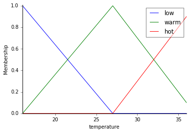

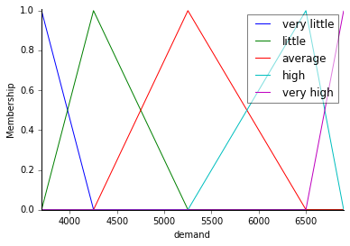

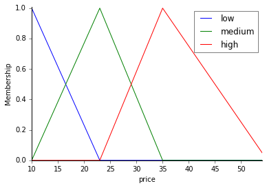

```python
temperature= ctrl.Antecedent(np.arange(16,37,1),'temperature')
demand=ctrl.Antecedent(np.arange(3700,6900,1),'demand')
price=ctrl.Consequent(np.arange(10,55,1),'price')


a1=temperature['low']=fuzz.trimf(temperature.universe,[16,16,27])
a2=temperature['warm']=fuzz.trimf(temperature.universe,[16,27,37])
a3=temperature['hot']=fuzz.trimf(temperature.universe,[27,37,37])

temperature.view()

b1=demand['very little']=fuzz.trimf(demand.universe,[3700,3700,4250])
b2=demand['little']=fuzz.trimf(demand.universe,[3700,4250,5250])
b3=demand['average']=fuzz.trimf(demand.universe,[4250,5250,6500])
b4=demand['high']=fuzz.trimf(demand.universe,[5250,6500,6900])
b5=demand['very high']=fuzz.trimf(demand.universe,[6500,6900,6900])

demand.view()

c1=price['low']=fuzz.trimf(price.universe,[0,10,23])
c2=price['medium']=fuzz.trimf(price.universe,[10,23,35])
c3=price['high']=fuzz.trimf(price.universe,[23,35,55])

price.view()
```

Setup the fuzzy rules

```python
rule1= ctrl.Rule(temperature['low']& demand['very little'],price['low'])
rule2= ctrl.Rule(temperature['low']& demand['little'],price['medium'])
rule3= ctrl.Rule(temperature['low']& demand['average'],price['medium'])
rule4= ctrl.Rule(temperature['low']& demand['high'],price['medium'])
rule5= ctrl.Rule(temperature['low']& demand['very high'],price['high'])
rule6= ctrl.Rule(temperature['warm']& demand['very little'],price['low'])
rule7= ctrl.Rule(temperature['warm']& demand['little'],price['medium'])
rule8= ctrl.Rule(temperature['warm']& demand['average'],price['medium'])
rule9= ctrl.Rule(temperature['warm']& demand['high'],price['medium'])
rule10= ctrl.Rule(temperature['warm']& demand['very high'],price['high'])
rule11= ctrl.Rule(temperature['hot']& demand['very little'],price['low'])
rule12= ctrl.Rule(temperature['hot']& demand['little'],price['medium'])
rule13= ctrl.Rule(temperature['hot']& demand['average'],price['medium'])
rule14= ctrl.Rule(temperature['hot']& demand['high'],price['high'])
rule15= ctrl.Rule(temperature['hot']& demand['very high'],price['high'])
```

Creating control system:

```python
pricing_ctrl = ctrl.ControlSystem([rule1, rule2, rule3,rule4, rule5, rule6, rule7, rule8, rule9, rule10, rule11, rule12,rule13, rule14,rule15])
pricing = ctrl.ControlSystemSimulation(pricing_ctrl)
```

[output not shown]

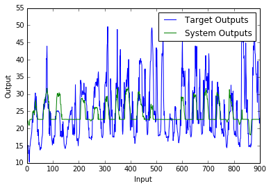

```python
count=0
intput1=new_data_set[:,0]
intput2=new_data_set[:,1]
targetOutput=np.array(new_data_set[:,2])
System_outputs=np.zeros(901,dtype=np.float64)
while count<901:
    pricing.input['temperature']= intput1[count]
    pricing.input['demand']=intput2[count]
    pricing.compute()
    System_outputs[count]=pricing.output['price']    ### Save each output in the object 'System_outputs'
    count+=1
#%%
#print(System_outputs)  # should have three values/elements
Err=np.sum(np.absolute(targetOutput-System_outputs)/np.absolute(targetOutput))/901
print('The Average Relative Error Value for traing dataset is', Err)


plt.plot(targetOutput)

plt.plot(System_outputs)
plt.xlabel('Input')
plt.ylabel('Output')
plt.title('')
plt.legend(['Target Outputs', 'System Outputs'])
plt.show()
```

apply on testing dataset

```
The Average Relative Error Value for testing dataset is 0.2245315505529717
```

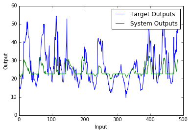

```python
#testing dataset
count=0
intput1=p_new_testing[:,0]
intput2=p_new_testing[:,5]
targetOutput=p_new_testing[:,6]

System_outputs=np.zeros(485,dtype=np.float64)
while count<485:
    pricing.input['temperature']= intput1[count]
    pricing.input['demand']=intput2[count]
    pricing.compute()
    System_outputs[count]=pricing.output['price']    ### Save each output in the object 'System_outputs'
    count+=1
System_outputs
Err=np.sum(np.absolute(targetOutput-System_outputs)/np.absolute(targetOutput))/485
print('The Average Relative Error Value for testing dataset is', Err)
plt.cla
plt.clf
plt.figure()
plt.plot(targetOutput)
plt.plot(System_outputs)
plt.xlabel('Input')
plt.ylabel('Output')
plt.title('')
plt.legend(['Target Outputs', 'System Outputs'])
plt.show()
```